# Homework1_Guanlong Fu

Guanlong

2018年2月1日

Abstract

This is homework 1 to learn to use R markdown to output well formulated documents with texts, figures and results. The aim of the exercise is to do a monte-carlo simulation to empirically calcualte the cdf of the standard normal distribution and compare to the result to the **true** cdf to get a idea of the size of the magnitude.

## Mathematical equation

We what approximate the cdf of the standard normal distribution N(0,1), which is given as follows:

$$\Phi(t) = \int_{-\infty}^{t} \frac{1}{\sqrt{2\pi}} e^{-y^2/2} ~ dy,$$
by the following equation:
$$\hat{\Phi}(t)= \frac{1}{n}\sum_{i=1}^{n}I(X{i} \leq t ),$$
First we write a function named “empirical_cdf_sdnormal to calculate the above estimated empirical cdf of N(0,1)

```r
empirical_cdf_sdnormal <- function (n,t)
{
  x <- rnorm(n, mean = 0, sd = 1)
  b = 0
  for (i in 1:n) {
    if ( x[i] <= t) {b=b+1}
  }
  empirical_cdf <- b/n

  return(empirical_cdf)

}
```

Then We code nexted loops to calculate the value of $\hat{\Phi}(t)$ for each of three value of $n=\{ 10^{2},10^{3},10^{4}\}$ and for the each of the nine values of t. Where the matrix “Phi_hat” is the calclated cdf for the combnation of $3\times9=27$ (n,t) , and repeated for 100 times for each (n,t) combnation. “bias” is the corresponding bias for each (n,t) combnation in each repitition.

Note here “Phi_hat” is a $3\times900$ matrix, each rown represent the estimates corresponding to a n value, and every 100 column stands for estimates corresponding to a t value. the matrix is too large to be shown completely, so we will first row of each matrix

```r
Phi_hat <- matrix(0,3,900)  # each row represents a n value, each 100 clo represents a t value
bias <- matrix(0,3,900) # bias matrix

n <- c(100,1000,10000)
t <- c(0.0,0.67,0.84,1.28,1.65,2.32,2.58,3.09,3.72)

for (i in 1:length(n)) {
  for (j in 1: length(t)) {
     for (k in (1:100)) {
       Phi_hat[i,100*(j-1)+k] <- empirical_cdf_sdnormal(n[i],t[j])  # 100*(j-1)+k, for the each 100 elements corresponding to the same value of t
       bias[i,100*(j-1)+k] <- Phi_hat[i,100*(j-1)+k]-pnorm(t[j])    # calculate the bias

       }

  }

}
Phi_hat[1,]
```

```
##   [1] 0.50 0.54 0.56 0.40 0.53 0.53 0.48 0.54 0.46 0.48 0.48 0.50 0.50 0.49
##  [15] 0.52 0.39 0.49 0.52 0.51 0.49 0.54 0.58 0.46 0.47 0.48 0.46 0.41 0.51
##  [29] 0.54 0.46 0.59 0.49 0.55 0.45 0.53 0.53 0.48 0.54 0.47 0.53 0.45 0.52
##  [43] 0.59 0.45 0.49 0.54 0.55 0.50 0.49 0.44 0.51 0.44 0.48 0.53 0.61 0.48
##  [57] 0.50 0.52 0.40 0.39 0.47 0.47 0.50 0.39 0.51 0.50 0.51 0.48 0.49 0.52
##  [71] 0.46 0.42 0.50 0.55 0.45 0.63 0.52 0.41 0.44 0.49 0.44 0.44 0.43 0.49
##  [85] 0.48 0.43 0.44 0.57 0.46 0.43 0.42 0.44 0.52 0.44 0.41 0.53 0.46 0.46
##  [99] 0.57 0.45 0.70 0.81 0.71 0.74 0.70 0.74 0.82 0.72 0.79 0.76 0.74 0.65
## [113] 0.76 0.68 0.77 0.68 0.72 0.70 0.70 0.68 0.80 0.67 0.74 0.77 0.64 0.79
## [127] 0.74 0.75 0.70 0.82 0.78 0.77 0.79 0.76 0.72 0.70 0.72 0.78 0.74 0.79
## [141] 0.77 0.80 0.76 0.77 0.76 0.79 0.77 0.76 0.81 0.71 0.73 0.83 0.81 0.80
## [155] 0.73 0.82 0.70 0.73 0.76 0.75 0.81 0.66 0.79 0.84 0.73 0.73 0.74 0.69
## [169] 0.76 0.80 0.75 0.66 0.75 0.75 0.73 0.76 0.75 0.84 0.71 0.80 0.72 0.77
## [183] 0.75 0.71 0.76 0.71 0.79 0.79 0.72 0.76 0.79 0.80 0.75 0.70 0.61 0.73
## [197] 0.78 0.72 0.66 0.68 0.78 0.78 0.81 0.79 0.82 0.73 0.82 0.70 0.81 0.73
```

[output cut: 50 more lines]

```r
bias[1,]
```

```
##   [1]  0.000000e+00  4.000000e-02  6.000000e-02 -1.000000e-01  3.000000e-02
##   [6]  3.000000e-02 -2.000000e-02  4.000000e-02 -4.000000e-02 -2.000000e-02
##  [11] -2.000000e-02  0.000000e+00  0.000000e+00 -1.000000e-02  2.000000e-02
##  [16] -1.100000e-01 -1.000000e-02  2.000000e-02  1.000000e-02 -1.000000e-02
##  [21]  4.000000e-02  8.000000e-02 -4.000000e-02 -3.000000e-02 -2.000000e-02
##  [26] -4.000000e-02 -9.000000e-02  1.000000e-02  4.000000e-02 -4.000000e-02
##  [31]  9.000000e-02 -1.000000e-02  5.000000e-02 -5.000000e-02  3.000000e-02
##  [36]  3.000000e-02 -2.000000e-02  4.000000e-02 -3.000000e-02  3.000000e-02
##  [41] -5.000000e-02  2.000000e-02  9.000000e-02 -5.000000e-02 -1.000000e-02
##  [46]  4.000000e-02  5.000000e-02  0.000000e+00 -1.000000e-02 -6.000000e-02
##  [51]  1.000000e-02 -6.000000e-02 -2.000000e-02  3.000000e-02  1.100000e-01
##  [56] -2.000000e-02  0.000000e+00  2.000000e-02 -1.000000e-01 -1.100000e-01
##  [61] -3.000000e-02 -3.000000e-02  0.000000e+00 -1.100000e-01  1.000000e-02
##  [66]  0.000000e+00  1.000000e-02 -2.000000e-02 -1.000000e-02  2.000000e-02
##  [71] -4.000000e-02 -8.000000e-02  0.000000e+00  5.000000e-02 -5.000000e-02
```

[output cut: 165 more lines]

The boxplot is generated for all the t values

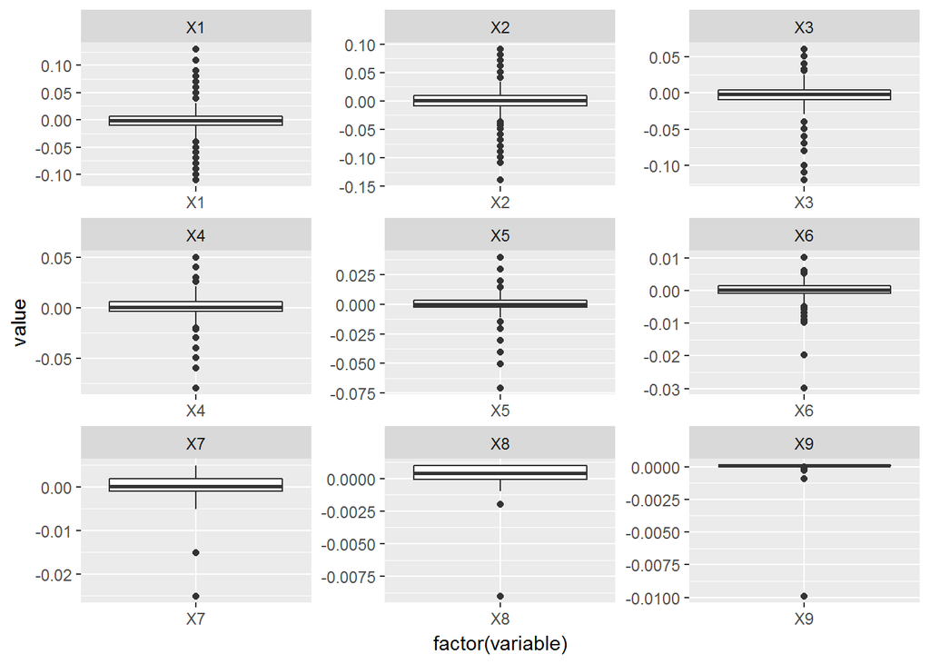